# XAI_Prototype_Final

Lets Load the data

```python
import pandas as pd
import seaborn as sns
from sklearn.model_selection import train_test_split

import warnings
warnings.filterwarnings('ignore')
```

```python
#Loading the data
df = pd.read_csv('survey.csv')
df.head()
```

|  | Timestamp | Age | Gender | Country | state | self_employed | family_history | treatment | work_interfere | no_employees | ... | leave | mental_health_consequence | phys_health_consequence | coworkers | supervisor | mental_health_interview | phys_health_interview | mental_vs_physical | obs_consequence | comments |
| --- | --- | --- | --- | --- | --- | --- | --- | --- | --- | --- | --- | --- | --- | --- | --- | --- | --- | --- | --- | --- | --- |
| 0 | 2014-08-27 11:29:31 | 37 | Female | United States | IL | NaN | No | Yes | Often | 6-25 | ... | Somewhat easy | No | No | Some of them | Yes | No | Maybe | Yes | No | NaN |
| 1 | 2014-08-27 11:29:37 | 44 | M | United States | IN | NaN | No | No | Rarely | More than 1000 | ... | Don't know | Maybe | No | No | No | No | No | Don't know | No | NaN |
| 2 | 2014-08-27 11:29:44 | 32 | Male | Canada | NaN | NaN | No | No | Rarely | 6-25 | ... | Somewhat difficult | No | No | Yes | Yes | Yes | Yes | No | No | NaN |
| 3 | 2014-08-27 11:29:46 | 31 | Male | United Kingdom | NaN | NaN | Yes | Yes | Often | 26-100 | ... | Somewhat difficult | Yes | Yes | Some of them | No | Maybe | Maybe | No | Yes | NaN |
| 4 | 2014-08-27 11:30:22 | 31 | Male | United States | TX | NaN | No | No | Never | 100-500 | ... | Don't know | No | No | Some of them | Yes | Yes | Yes | Don't know | No | NaN |

5 rows × 27 columns

Now lets Explore the data

```python
#Dropping non-defined column and Duplicates from the data.
# df.drop_duplicates(subset=None,keep='first',inplace=True)
# df.drop(columns="Unnamed: 0", inplace=True)

# Drop missing key columns
df = df.dropna(subset=['treatment'])

# Drop unnecessary columns
df = df.drop(columns=['Timestamp', 'comments', 'state'])

# Remove don't know option keeping only entries with benefits or not
df = df[df['benefits'].isin(['Yes', 'No'])]
```

```python
# check for null values
df.isnull().sum()
```

```
Age                            0
Gender                         0
Country                        0
self_employed                 11
family_history                 0
treatment                      0
work_interfere               150
no_employees                   0
remote_work                    0
tech_company                   0
benefits                       0
care_options                   0
wellness_program               0
seek_help                      0
anonymity                      0
leave                          0
mental_health_consequence      0
phys_health_consequence        0
coworkers                      0
supervisor                     0
mental_health_interview        0
phys_health_interview          0
mental_vs_physical             0
obs_consequence                0
dtype: int64
```

```python
import re

# Clean Gender column using regex as there are many misspelled or joke entries in the dataset
def normalize_gender(val):
    val = str(val).strip().lower()
    if re.search(r'\bfem(ale)?\b', val):
        return 'Female'
    if re.search(r'\bmale\b', val):
        return 'Male'
    return None

df['Gender'] = df['Gender'].apply(normalize_gender)
df = df[df['Gender'].isin(['Male', 'Female'])]
df['Gender'].value_counts()
```

```
Gender
Male      559
Female    136
Name: count, dtype: int64
```

```python
import pandas.api.types as ptypes   # Need this for check
# Imputing the Null values
for col in df.columns:
    # if df.isnull().sum()[col]!=0:
    #     df[col].fillna((df[col].mean()), inplace=True)

    # survey.csv has mostly categorical columns
    if df[col].isnull().sum() > 0:
        if ptypes.is_numeric_dtype(df[col]):
            df[col].fillna(df[col].mean(), inplace=True)

        # address numerical columns i.e. age
        else:
            df[col].fillna(df[col].mode()[0], inplace=True)


# check for null values again
df.isnull().sum().sum()
```

```
0
```

```python
# df['treatment'].replace(0.0, 0, inplace=True)
# df['treatment'].replace(1.0, 1, inplace=True)
#df["Default"] = pd.to_numeric(df["Default"], errors='coerce')

df['treatment'] = df['treatment'].map({'Yes': 1, 'No': 0})
```

```python
# a_list = df['treatment'].tolist()
# print(a_list[1:100])
print(df['treatment'].value_counts())
```

```
treatment
1    395
0    300
Name: count, dtype: int64
```

```python
# Define country group
df['country_group'] = df['Country'].apply(lambda x: 'United States' if x == 'United States' else 'Other')
print(df['country_group'].value_counts())
```

```
country_group
United States    400
Other            295
Name: count, dtype: int64
```

```python
# Define age group
df['age_group'] = df['Age'].apply(lambda x: '<35' if x < 35 else '35+')
print(df['age_group'].value_counts())
```

```
age_group
<35    474
35+    221
Name: count, dtype: int64
```

### IV and PDP Plots

```python
  ## Declaring class for IV and PDP functions:
from sklearn.ensemble import RandomForestClassifier

class IV_PDP:
    def __init__(self, data, in_independent_features, in_target_variable):
        """function to initialize class"""
        self.data = data
        y=self.data[in_target_variable]
        x=self.data.drop(columns=[in_target_variable])
        self.X_train, self.X_test, self.y_train, self.y_test = train_test_split(x, y, test_size=0.20, random_state=555) #, stratify=y)
        self.independent_features = in_independent_features
        self.target_variable = in_target_variable
        self.model = None
        self.predictions = None
        #self.PDP = None
        #self.IV = None

    def fit(self):
        """function to fit model"""
        self.model = RandomForestClassifier().fit(self.X_train, self.y_train)
        return self.model


    def predict(self):
        """function to predict using model"""
        self.predictions = self.model.predict(self.X_test)
        return self.predictions
```

```python
# Importing the .py file for below actions.
#Calling the defined functions
target_variable = "treatment"
# independent_features = ['Age', 'AppliedAmount', 'ExpectedLoss', 'LiabilitiesTotal']

independent_features = [
    'age_group', 'Gender', 'self_employed', 'remote_work',
    'tech_company', 'benefits', 'country_group'
]

# data_new=df[['Age', 'AppliedAmount', 'ExpectedLoss', 'LiabilitiesTotal', 'Default']]
data_new = df[[
    'age_group', 'Gender', 'self_employed', 'remote_work',
    'tech_company', 'benefits', 'country_group', 'treatment'
]]

# Encode binary categorical features
data_new['age_group'] = data_new['age_group'].map({'<35': 0, '35+': 1})
data_new['Gender'] = data_new['Gender'].map({'Male': 1, 'Female': 0})
data_new['self_employed'] = data_new['self_employed'].map({'Yes': 1, 'No': 0})
data_new['remote_work'] = data_new['remote_work'].map({'Yes': 1, 'No': 0})
data_new['tech_company'] = data_new['tech_company'].map({'Yes': 1, 'No': 0})
data_new['benefits'] = data_new['benefits'].map({'Yes': 1, 'No': 0})
data_new['country_group'] = data_new['country_group'].map({'United States': 1, 'Other': 0})


data_new.head()
```

|  | age_group | Gender | self_employed | remote_work | tech_company | benefits | country_group | treatment |
| --- | --- | --- | --- | --- | --- | --- | --- | --- |
| 0 | 1 | 0 | 0 | 0 | 1 | 1 | 1 | 1 |
| 2 | 0 | 1 | 0 | 0 | 1 | 0 | 0 | 0 |
| 3 | 0 | 1 | 0 | 0 | 1 | 0 | 0 | 1 |
| 4 | 0 | 1 | 0 | 1 | 1 | 1 | 1 | 0 |
| 5 | 0 | 1 | 0 | 0 | 1 | 1 | 1 | 0 |

```python
data_new.shape
```

```
(695, 8)
```

```python
full_model = IV_PDP(data_new,independent_features,target_variable)
n_model = full_model.fit()

full_model_predictions = full_model.predict()
```

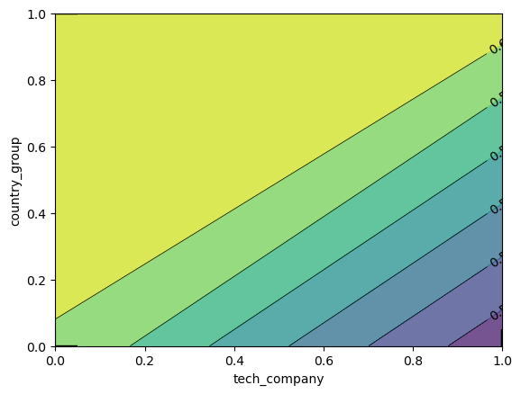

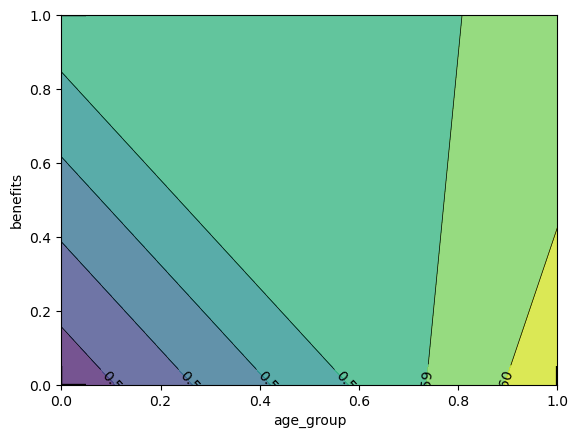

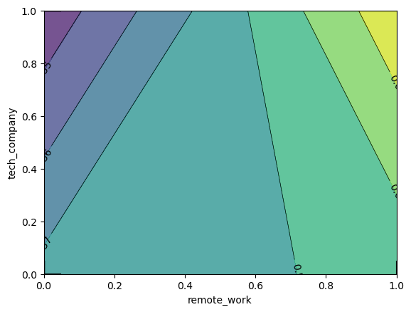

```python
import matplotlib.pyplot as plt
from sklearn.inspection import PartialDependenceDisplay
# pdp_data=df[['Age', 'AppliedAmount', 'ExpectedLoss', 'LiabilitiesTotal']]
pdp_data = data_new[[
    'age_group', 'Gender', 'self_employed', 'remote_work',
    'tech_company', 'benefits', 'country_group'
]]

features = [0, 1, 2, 3, 4, 5, 6]
# PartialDependenceDisplay.from_estimator(n_model, pdp_data, features)

# Categorical and encoded dataset does not work well with PDP
# Working at a Tech company and in a certain region significantly increases the likelihood of seeking treatment.
PartialDependenceDisplay.from_estimator(n_model, pdp_data, [(4, 6)])

# Older individuals with access to mental health benefits are much more likely to seek treatment.
PartialDependenceDisplay.from_estimator(n_model, pdp_data, [(0, 5)])

# The combination of working remotely and being in tech is strongly associated with seeking treatment.
PartialDependenceDisplay.from_estimator(n_model, pdp_data, [(3, 4)])


plt.show()
```

#### IV and PDP Plots Summary

**Overview:**

Partial Dependence Plots (PDPs) were used with a Random Forest Classifier to evaluate how binary-encoded features influence the predicted likelihood of the target variable (treatment). The model was trained on preprocessed features such as age group, employment, tech affiliation, and mental health benefits access. All categorical features were encoded as binary also age due to skewed data.

```python
df['treatment'].head()
```

```
0    1
2    0
3    1
4    0
5    0
Name: treatment, dtype: int64
```

```python
data_new.shape
```

```
(695, 8)
```

```python
from mightypy.stats import WOE_IV
target_map = {0.0: 'False', 1.0: 'True'}

data_new.insert(loc=data_new.shape[1], column='label', value=data_new['treatment'].map(target_map))
data_new.head()
```

|  | age_group | Gender | self_employed | remote_work | tech_company | benefits | country_group | treatment | label |
| --- | --- | --- | --- | --- | --- | --- | --- | --- | --- |
| 0 | 1 | 0 | 0 | 0 | 1 | 1 | 1 | 1 | True |
| 2 | 0 | 1 | 0 | 0 | 1 | 0 | 0 | 0 | False |
| 3 | 0 | 1 | 0 | 0 | 1 | 0 | 0 | 1 | True |
| 4 | 0 | 1 | 0 | 1 | 1 | 1 | 1 | 0 | False |
| 5 | 0 | 1 | 0 | 0 | 1 | 1 | 1 | 0 | False |

```python
# Custom function for calculating WOE and IV, due to all features being binary values
# Features used are yes and no answers which did not work well with WOE_IV
def calculate_and_plot_iv(df, feature, target, event='True', non_event='False'):
    # IV calculation
    total_event = (df[target] == event).sum()
    total_non_event = (df[target] == non_event).sum()

    iv_data = (
        df.groupby(feature)[target]
        .value_counts()
        .unstack()
        .fillna(0)
        .rename(columns={event: 'event', non_event: 'non_event'})
    )

    iv_data['dist_event'] = iv_data['event'] / total_event
    iv_data['dist_non_event'] = iv_data['non_event'] / total_non_event

    iv_data = iv_data[(iv_data['dist_event'] > 0) & (iv_data['dist_non_event'] > 0)]
    iv_data['woe'] = np.log(iv_data['dist_event'] / iv_data['dist_non_event'])
    iv_data['iv'] = (iv_data['dist_event'] - iv_data['dist_non_event']) * iv_data['woe']
    iv = iv_data['iv'].sum()

    # Plotting
    plot_custom_woe_iv(iv_data[['event', 'non_event', 'woe', 'iv']], feature, iv)

    return iv_data[['event', 'non_event', 'woe', 'iv']], iv
```

```python
import matplotlib.pyplot as plt
import numpy as np

def plot_custom_woe_iv(iv_table, feature_name, iv_score):
    categories = iv_table.index.astype(str)
    event_counts = iv_table['event']
    non_event_counts = iv_table['non_event']
    woe_vals = iv_table['woe']
    iv_vals = iv_table['iv']

    x = np.arange(len(categories))

    fig, (ax_woe, ax_deciles) = plt.subplots(1, 2, figsize=(14, 5), gridspec_kw={'width_ratios': [1, 1.2]})

    # WoE Bar Chart
    ax_woe.bar(x, woe_vals, color='lightblue', edgecolor='black')
    ax_woe.set_xticks(x)
    ax_woe.set_xticklabels(categories, rotation=0)
    ax_woe.set_ylabel("Weight of Evidence")
    ax_woe.set_title("Weight Of Evidence")

    # Annotate WoE values
    for i, val in enumerate(woe_vals):
        ax_woe.text(i, val + 0.02 * np.sign(val), f"{val:.2f}", ha='center', va='bottom' if val >= 0 else 'top')

    # Deciles Chart (Stacked)
    ax_deciles.bar(x, event_counts, label='True', color='salmon', edgecolor='black')
    ax_deciles.bar(x, non_event_counts, bottom=event_counts, label='False', color='mediumseagreen', edgecolor='black')
    ax_deciles.set_xticks(x)
    ax_deciles.set_xticklabels(categories, rotation=0)
    ax_deciles.set_ylabel("Count")
    ax_deciles.set_title("Deciles")
    ax_deciles.legend()

    # Annotate counts
    for i in range(len(x)):
        ax_deciles.text(i, event_counts.iloc[i] / 2, str(event_counts.iloc[i]), ha='center', va='center', fontsize=9)
        ax_deciles.text(i, event_counts.iloc[i] + non_event_counts.iloc[i] / 2, str(non_event_counts.iloc[i]),
                        ha='center', va='center', fontsize=9)

    # Title
    fig.suptitle(f"{feature_name} \nInformation Value: {iv_score:.4f}", fontsize=13, y=1.05)
    fig.tight_layout()
    plt.show()
```

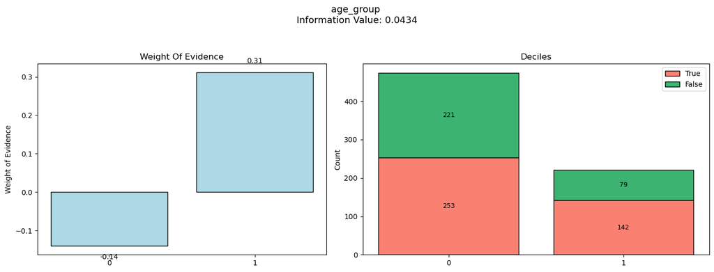

```python
iv_table, iv_score = calculate_and_plot_iv(data_new, 'age_group', 'label')
```

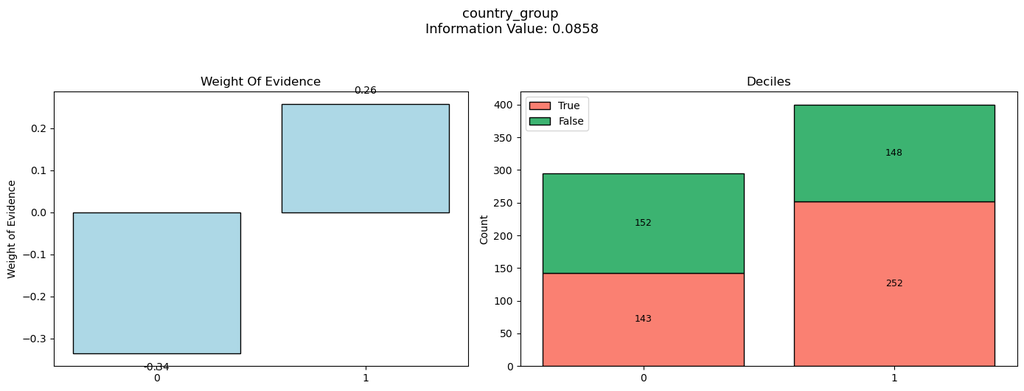

```python
iv_table, iv_score = calculate_and_plot_iv(data_new, 'country_group', 'label')
```

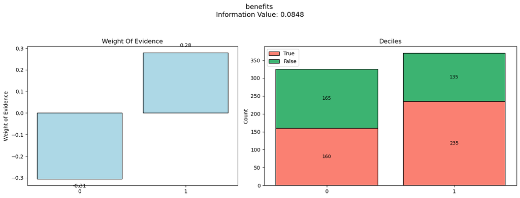

```python
iv_table, iv_score = calculate_and_plot_iv(data_new, 'benefits', 'label')
```

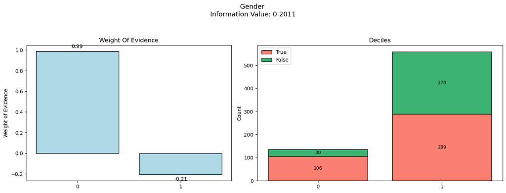

```python
iv_table, iv_score = calculate_and_plot_iv(data_new, 'Gender', 'label')
```

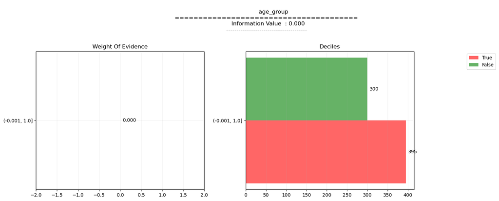

```python
# Reason for using cutom WOE and IV for the dataset
# Unfortunately using this was not viable due to all features showing this same graph and can only be shown with 'n_buckets=1'
woe_iv_obj = WOE_IV(event='True', non_event='False', target_col='label',bucket_col='age_group', n_buckets=1)
woe, iv = woe_iv_obj.values(data_new)
fig = woe_iv_obj.plot(figsize=(15,6))
fig.tight_layout();
```

```python
### if you are getting ValueError: Bin edges must be unique, play around with the n_buckets value
### the smaller the number of buckets, the less accurate, but you will not have the error
### get the number to the largest possible if you get an error.
### if not, then let the program do its job

# woe_iv_obj = WOE_IV(event='True', non_event='False', target_col='label',bucket_col='country_group', n_buckets=1)
# woe, iv = woe_iv_obj.values(data_new)
# fig = woe_iv_obj.plot(figsize=(15,6))
# fig.tight_layout();
```

#### Information Value and WoE Review

Information value is one of the most useful techniques to select important variables in a model. It helps to rank variables based on their importance and helps to determine the predictive power of the variable.

The underlying concepts of the IV Plots are weight of evidence (WoE) and the information value (IV). WoE helps us quantify the predictive power of a feature on the output, and the IV uses WoE to assign a score (IV) that can be used to compare and prioritize the features.This simple technique can help us compare the different features in a single scale and prioritize them based on their influence on the output.

#### Most Influential IV/WoE plots:

`Gender` — IV = 0.2011

- Interpretation: A strong indicator of treatment-seeking behavior, possibly reflecting gender differences in mental health outreach.

`country_group` — IV = 0.0858

- Suggests location/culture impacts willingness or access to seek treatment.

`benefits` — IV = 0.0848

- Indicates that access to benefits (e.g., insurance, paid leave) is a significant factor.

`age_group` — IV = 0.0434

- Although a weaker indicator than others this does show that age does play a role in the models predictiveness although age is masked split between 35+ and under into two groups. Without this encoding the model will show a significant bias towards certain ages to underepresentation.

### Functions Call for Split and Compare Quantiles

```python
def ret_tag(val):
        for i in range(10):
            if val in categories[i]:
                return tags[i]

def zero_list_maker(n):
        list_of_zeros = [0] * n
        return list_of_zeros
```

```python
def bar_width_per_quantile2(SCQ_view, label_filter):
    view_filtered = SCQ_view[SCQ_view['treatment'] == label_filter]
    view_filtered['Tag'] = view_filtered['Score2'].map(lambda x: ret_tag(x))
    len_view_filtered = len(view_filtered)
    view_filtered['ID']=view_filtered.index
    count_pertag_filtered = view_filtered[['ID', 'Tag']].groupby(['Tag']).count().rename(columns={'ID': 'Count'})
    count_pertag_filtered['Perc'] = count_pertag_filtered['Count'] / len(SCQ_view) * 100

    Amt = view_filtered[['ID', 'Tag', 'Amount']].groupby(['Tag'])['Amount'].sum()
    # Amt = (Amt/1000).to_list()
    # sc = count_pertag_filtered['Perc'].tolist()
    # sc = zero_list_maker(10 - len(sc)) + sc
    Amt = Amt.to_list()
    Amt = zero_list_maker(len(tags) - len(Amt)) + Amt

    sc = count_pertag_filtered['Perc'].tolist()
    sc = zero_list_maker(len(tags) - len(sc)) + sc

    return sc, Amt
```

```python
## Declaring function for Split and Compare Quantiles Plots:
def Show_quantile_label(df1,df2):
    fig, (ax1, ax2) = plt.subplots(1, 2, figsize=(20, 10))

    margin = 0.05
    width = (1.-2.*margin)/2
    if df2 is None:
        pal = sns.color_palette("RdYlBu", len(df1['Range']))
        chart = df1.set_index('Range').drop(columns=['Label 1'])
        chart2 = df1.set_index('Range').drop(columns=['Label 0'])

    elif df1 is None:
        pal = sns.color_palette("RdYlBu", len(df2['Range']))
        chart = df2.set_index('Range').drop(columns=['Amount:1'])
        chart2 = df2.set_index('Range').drop(columns=['Amount:0'])

    chart.T.plot.bar(stacked=True, color = pal, grid=True, ax=ax1, width=width, legend=False)
    for rect in ax1.patches:
        height = rect.get_height()
        width = rect.get_width()
        x = rect.get_x()
        y = rect.get_y()
        label_text = f'{height:.2f}'
        label_x = x + width/2
        label_y = (y + height/2)
        ax1.text(label_x, label_y, label_text, ha='center', va='center', fontsize=12)


    chart2.T.plot.bar(stacked=True, color = pal, grid=True, ax=ax2, width=width, legend=False)
    for rect in ax2.patches:
        height = rect.get_height()
        width = rect.get_width()
        x = rect.get_x()
        y = rect.get_y()
        label_text = f'{height:.2f}'
        label_x = x + width/2
        label_y = (y + height/2)
        ax2.text(label_x, label_y, label_text, ha='center', va='center', fontsize=12)


    plt.tight_layout()  # otherwise the right y-label is slightly clipped
    plt.legend()
    plt.show()
```

Split and Compare Quantile Plots: Default Percentage Errors

```python
from XAI_Prototype_Final import SCQ
```

```python
#Calling the above defined functions
#1 For Class SCQ
# target_variable = "Default"
# independent_features = ['Age', 'AppliedAmount', 'ExpectedLoss', 'LiabilitiesTotal']
# data_new=df[['Default','Age', 'AppliedAmount', 'ExpectedLoss', 'LiabilitiesTotal']]

target_variable = "treatment"
# independent_features = ['Age', 'AppliedAmount', 'ExpectedLoss', 'LiabilitiesTotal']

independent_features = [
    'age_group', 'Gender', 'self_employed', 'remote_work',
    'tech_company', 'benefits', 'country_group'
]

# data_new=df[['Age', 'AppliedAmount', 'ExpectedLoss', 'LiabilitiesTotal', 'Default']]
# data_new = df[[
#     'age_group', 'Gender', 'self_employed', 'remote_work',
#     'tech_company', 'benefits', 'country_group', 'treatment'
# ]]

scq = SCQ(data_new,independent_features,target_variable)
scq.fit()
SCQ_predictions = scq.predict()
scq.X_test['dummy_amount'] = 1  # dummy amount for true
SCQ_view = scq.create_view("dummy_amount",'Score',['treatment','Score','Amount'])
# SCQ_view = scq.create_view("Gender",'Score',['treatment','Score','Amount'])

#2 For ret_tags, zero_lists and Categories
i=5
cuts_by_quantile = pd.qcut(SCQ_view['Score2'], 11, duplicates='drop')
categories = cuts_by_quantile.value_counts().index.categories
left_bounds = categories.left
right_bounds = categories.right
tags = range(1, 11)

#3 For class bar_width_per_quantile2
sc1, amt1 = bar_width_per_quantile2(SCQ_view, 1)
sc0, amt0 = bar_width_per_quantile2(SCQ_view, 0)

#Defining dataframes for plotting
name = [str(left_bounds[i])+'-'+str(right_bounds[i]) for i in range(10)]

data_p = [(name[i], sc1[i], sc0[i]) for i in range(10)]
data_amt = [(name[i], amt1[i], amt0[i]) for i in range(10)]

df1 = pd.DataFrame(columns=["Range","Label 1", "Label 0"],data=data_p)
df2 = pd.DataFrame(columns=["Range", 'Amount:1', "Amount:0"],data=data_amt)
```

The split and compare quantiles helps us define a decision threshold for a classification problem by giving a clear understanding of the impact of our decision on the confusion matrix and evaluate if the model helps meet the business objectives.

To implement it, we divide our dataset into equal quantiles and then split it by favourable and unfavourable outcomes.

This should be used by the product owner and the business analysts to determine the optimum decision boundary that helps minimize the false positives and the negatives.

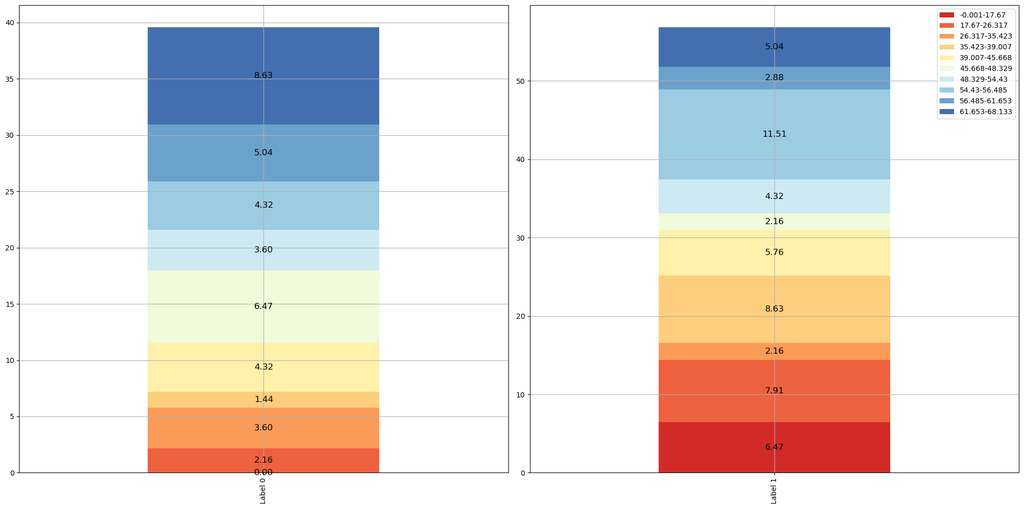

```python
Show_quantile_label(df1,None)
```

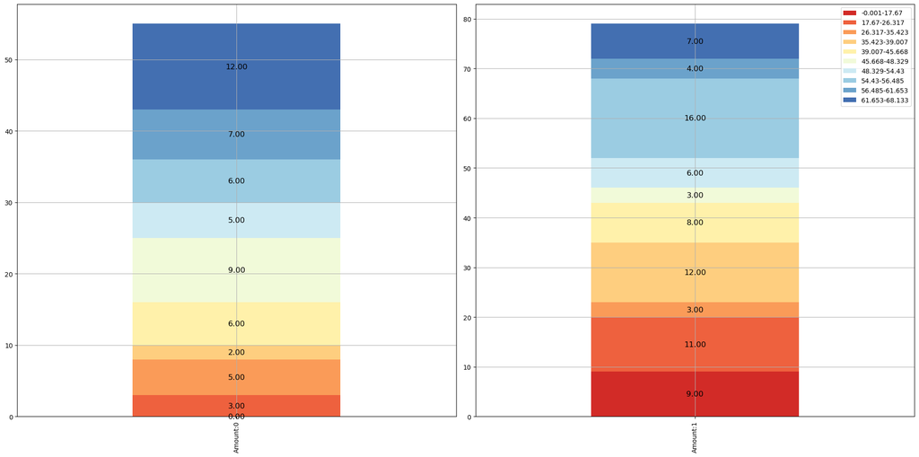

```python
Show_quantile_label(None, df2)
```

#### Interpretations:

For treatment = 1, the model tends to underpredict at lower quantiles (score range 0.0–35), as seen in the higher default/error rates in these bins.

Conversely, for treatment = 0, the model shows overprediction in the higher quantile bins (score range 56–68), suggesting possible false positives.

This disparity across bins indicates that the model's calibration is uneven—it performs differently across score ranges and class labels.

Such imbalance may point to model bias or instability, especially if protected features (e.g., gender, group, etc.) contribute heavily to the score.

**Responsible AI Implications:** This quantile-level analysis reveals potential predictive inequity—some groups may systematically receive higher or lower scores regardless of actual outcome, which can result in disparate treatment. Further review of feature contributions and counterfactuals is warranted to ensure fairness.

### Functions Call for GAM

Generalized Additive Models : GAM Plots

Linear models are inherently explainable but, as the name implies, do not capture nonlinearity. Generalized additive models are a nonlinear version of the generalized linear models and provide an explainable and flexible approach like linear models while capturing nonlinearity.

Since this is an additive model with a separate function for each feature, the impact of each feature is known at all times. There are no hidden inner workings of the model making the explanation difficult. This ability makes this a “glass box” model and deserves a strong consideration if your other options so far are black box models with additional explanation added.

```python
from XAI_Prototype_Final import GAM

# need this for binary data
from pygam import LogisticGAM
import scipy.sparse
```

```python
target_variable = "treatment"
# independent_features = ['Age', 'AppliedAmount', 'ExpectedLoss', 'LiabilitiesTotal']

independent_features = [
    'age_group', 'Gender', 'self_employed', 'remote_work',
    'tech_company', 'benefits', 'country_group'
]
# data_new=df [[
#     'age_group', 'Gender', 'self_employed', 'remote_work',
#     'tech_company', 'benefits', 'country_group'
# ]]
# data_new=df[['Default','Age', 'AppliedAmount', 'ExpectedLoss', 'LiabilitiesTotal']]

# gam = GAM(data_new,independent_features,target_variable)
# gam.fit()

# Convert selected feature columns to a dense float NumPy array
# Then extract target variable as a NumPy array
X = data_new[independent_features].astype(float).values
y = data_new[target_variable].values

# Add missing `.A` attribute to sparse matrices
scipy.sparse.csr_matrix.A = property(lambda self: self.toarray())

# Fit the model
model = LogisticGAM().fit(X, y)

# Reconstruct GAM and manually assign the trained model for evaluation
gam = GAM(data_new, independent_features, target_variable)
gam.model = model
GAM_train_acc, GAM_test_acc, GAM_summary = gam.predict()




print(f"Train Accuracy: {GAM_train_acc}\n")
print(f"Test Accuracy: {GAM_test_acc}\n")
GAM_train_acc
```

```
Train Accuracy: 0.60431654676259

Test Accuracy: 0.60431654676259
```

```
0.60431654676259
```

```python
# GAM.summary()

GAM_summary()
```

```
LogisticGAM
=============================================== ==========================================================
Distribution:                      BinomialDist Effective DoF:                                         8.0
Link Function:                        LogitLink Log Likelihood:                                   -448.167
Number of Samples:                          695 AIC:                                              912.3341
                                                AICc:                                             912.5969
                                                UBRE:                                               3.3219
                                                Scale:                                                 1.0
                                                Pseudo R-Squared:                                   0.0569
==========================================================================================================
Feature Function                  Lambda               Rank         EDoF         P > x        Sig. Code
================================= ==================== ============ ============ ============ ============
s(0)                              [0.6]                20           2.2          4.03e-02     *
s(1)                              [0.6]                20           1.2          4.36e-08     ***
s(2)                              [0.6]                20           1.2          8.19e-01
s(3)                              [0.6]                20           1.0          5.00e-01
s(4)                              [0.6]                20           1.0          9.97e-01
s(5)                              [0.6]                20           0.8          2.74e-01
s(6)                              [0.6]                20           0.7          3.74e-01
intercept                                              1            0.0          4.12e-07     ***
==========================================================================================================
Significance codes:  0 '***' 0.001 '**' 0.01 '*' 0.05 '.' 0.1 ' ' 1

WARNING: Fitting splines and a linear function to a feature introduces a model identifiability problem
         which can cause p-values to appear significant when they are not.

WARNING: p-values calculated in this manner behave correctly for un-penalized models or models with
         known smoothing parameters, but when smoothing parameters have been estimated, the p-values
         are typically lower than they should be, meaning that the tests reject the null too readily.
```

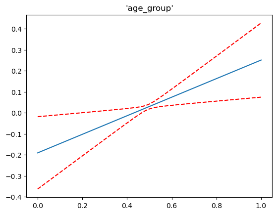

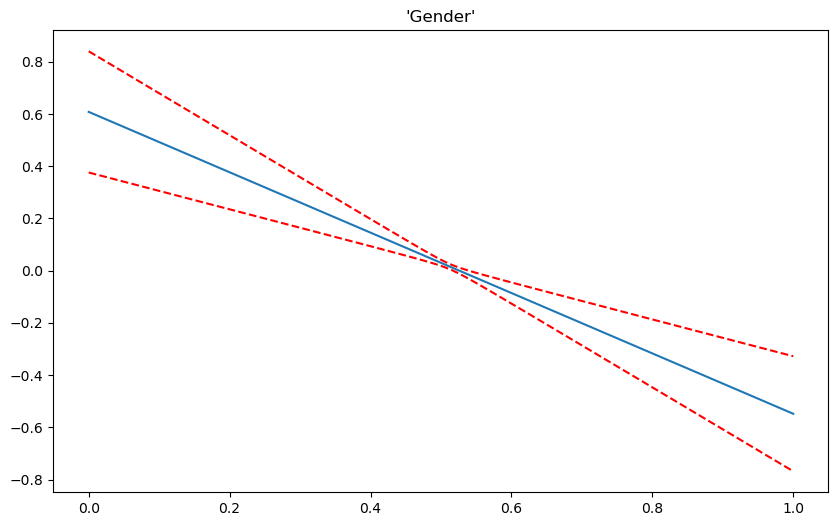

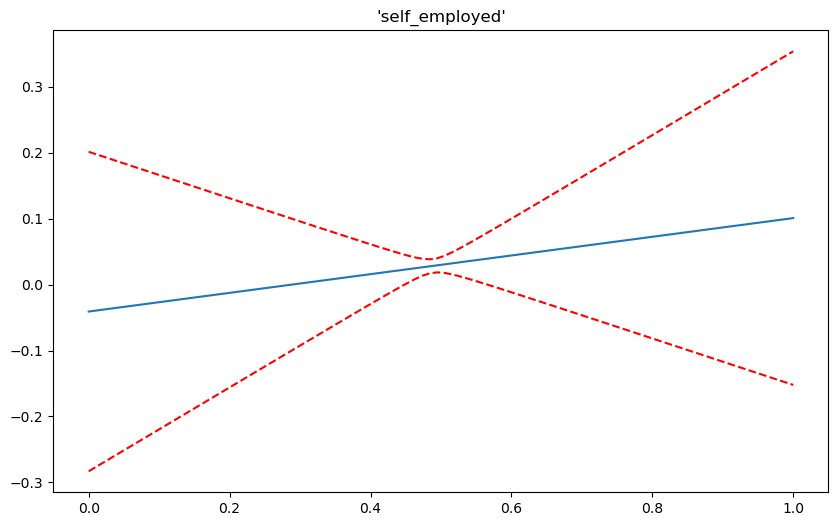

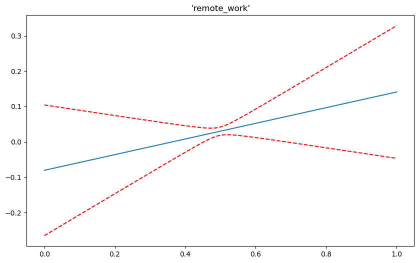

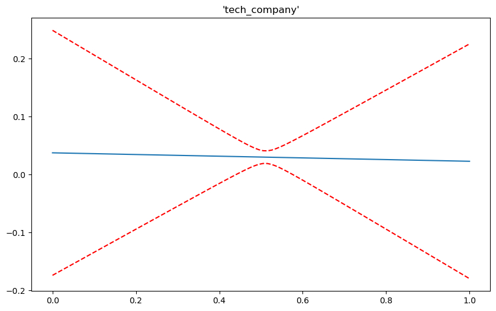

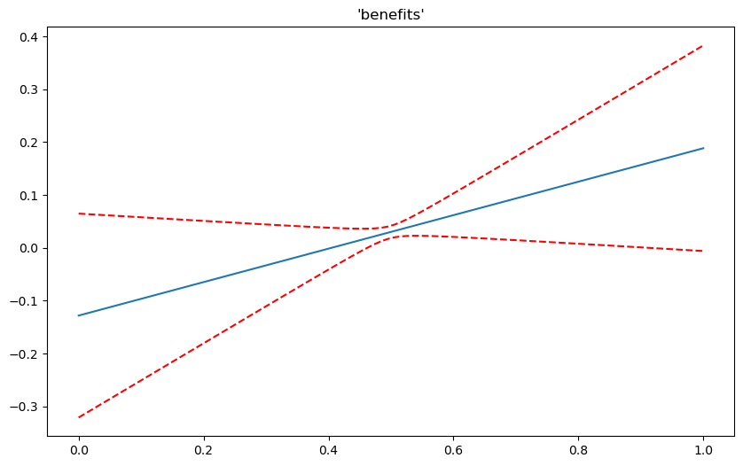

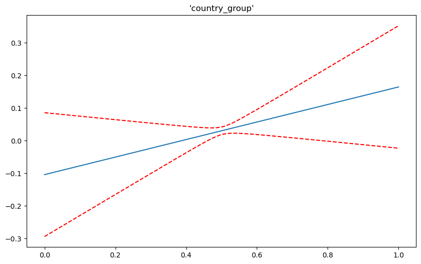

```python
scipy.sparse.csc_matrix.A = property(lambda self: self.toarray())
gam.GAM_PLOT()
```

### Functions Defined for CounterFactuals

CounterFactuals

```python
from XAI_Prototype_Final import CF
```

```python
# target_variable = "Default"
# independent_features = ['Age', 'AppliedAmount', 'ExpectedLoss', 'LiabilitiesTotal']

# data_new=df[['Default','Age', 'AppliedAmount', 'ExpectedLoss', 'LiabilitiesTotal']]

target_variable = "treatment"

independent_features = [
    'age_group', 'Gender', 'self_employed', 'remote_work',
    'tech_company', 'benefits', 'country_group'
]
data_new = data_new.drop(columns=["label"])



cf = CF(data_new,independent_features,target_variable)
cf.fit()
cf.dice_ml()
```

```
<dice_ml.explainer_interfaces.dice_random.DiceRandom at 0x29025a7f470>
```

CounterFactuals is a method for countering the fact or reversing the fact or identifying the changes in the features that would change the outcome thereby helping in explaining the Model's behaviour. For example many times we see client coming back with a question or seeking explainations for "What's next" or "What if". So Counterfactual tells the ways that would make the decision change or what could have been different in the customer’s data that could’ve meant a different outcome for them.

```python
# CF.CF_EXP()
cf.CF_EXP()
```

```
Query instance (original outcome : 0)
```

|  | age_group | Gender | self_employed | remote_work | tech_company | benefits | country_group | treatment |
| --- | --- | --- | --- | --- | --- | --- | --- | --- |
| 0 | 0 | 1 | 0 | 0 | 1 | 1 | 1 | 0 |

```
Diverse Counterfactual set (new outcome: 1.0)
```

|  | age_group | Gender | self_employed | remote_work | tech_company | benefits | country_group | treatment |
| --- | --- | --- | --- | --- | --- | --- | --- | --- |
| 0 | - | 0 | - | 1 | - | - | - | 1 |
| 1 | - | 0 | 1 | - | - | - | - | 1 |
| 2 | - | - | 1 | 1 | - | - | - | 1 |
| 3 | - | 0 | - | - | - | - | - | 1 |

#### Interpretations

**Original Prediction**: `0` (Not Treated)  
**Target Outcome**: `1` (Treated)

These results help identify actionable and interpretable levers that could impact decision outcomes in the current model.

### ----------------------------------------------------------------THE END------------------------------------------------------------------------------